# Assignment 04

Kevin Hu

03/10/2019

Required packages

```r
library(gapminder)
library(tidyverse)
library(scales)
```

## Original data

The original data that will be used to reshape is the “gapminder” dataset in R:

```r
DT::datatable(gapminder)
```

|  | country | continent | year | lifeExp | pop | gdpPercap |
| --- | --- | --- | --- | --- | --- | --- |
| 1 | Afghanistan | Asia | 1952 | 28.801 | 8425333 | 779.4453145 |
| 2 | Afghanistan | Asia | 1957 | 30.332 | 9240934 | 820.8530296 |
| 3 | Afghanistan | Asia | 1962 | 31.997 | 10267083 | 853.10071 |
| 4 | Afghanistan | Asia | 1967 | 34.02 | 11537966 | 836.1971382 |
| 5 | Afghanistan | Asia | 1972 | 36.088 | 13079460 | 739.9811058 |
| 6 | Afghanistan | Asia | 1977 | 38.438 | 14880372 | 786.11336 |
| 7 | Afghanistan | Asia | 1982 | 39.854 | 12881816 | 978.0114388 |
| 8 | Afghanistan | Asia | 1987 | 40.822 | 13867957 | 852.3959448 |
| 9 | Afghanistan | Asia | 1992 | 41.674 | 16317921 | 649.3413952 |
| 10 | Afghanistan | Asia | 1997 | 41.763 | 22227415 | 635.341351 |

[output cut: 1694 more lines]

## Exercise 1: Univariate Data Reshaping (Option 1)

### 1. Make a tibble with one row per year, and columns for life expectancy for two or more countries.

Codes and results:

```r
gap_wide <- gapminder %>%
  filter(continent == "Asia") %>% #filter the dataset to display only Asian countries
  pivot_wider(id_cols = year,
              names_from = country,
              values_from = lifeExp)
DT::datatable(gap_wide)
```

|  | year | Afghanistan | Bahrain | Bangladesh | Cambodia | China | Hong Kong, China | India | Indonesia | Iran | Iraq | Israel | Japan | Jordan | Korea, Dem. Rep. | Korea, Rep. | Kuwait | Lebanon | Malaysia | Mongolia | Myanmar | Nepal | Oman | Pakistan | Philippines | Saudi Arabia | Singapore | Sri Lanka | Syria | … |
| --- | --- | --- | --- | --- | --- | --- | --- | --- | --- | --- | --- | --- | --- | --- | --- | --- | --- | --- | --- | --- | --- | --- | --- | --- | --- | --- | --- | --- | --- | --- |
| 1 | 1952 | 28.801 | 50.939 | 37.484 | 39.417 | 44 | 60.96 | 37.373 | 37.468 | 44.869 | 45.32 | 65.39 | 63.03 | 43.158 | 50.056 | 47.453 | 55.565 | 55.928 | 48.463 | 42.244 | 36.319 | 36.157 | 37.578 | 43.436 | 47.752 | 39.875 | 60.396 | 57.593 | 45.883 | … |
| 2 | 1957 | 30.332 | 53.832 | 39.348 | 41.366 | 50.54896 | 64.75 | 40.249 | 39.918 | 47.181 | 48.437 | 67.84 | 65.5 | 45.669 | 54.081 | 52.681 | 58.033 | 59.489 | 52.102 | 45.248 | 41.905 | 37.686 | 40.08 | 45.557 | 51.334 | 42.868 | 63.179 | 61.456 | 48.284 | … |
| 3 | 1962 | 31.997 | 56.923 | 41.216 | 43.415 | 44.50136 | 67.65 | 43.605 | 42.518 | 49.325 | 51.457 | 69.39 | 68.73 | 48.126 | 56.656 | 55.292 | 60.47 | 62.094 | 55.737 | 48.251 | 45.108 | 39.393 | 43.165 | 47.67 | 54.757 | 45.914 | 65.798 | 62.192 | 50.305 | … |
| 4 | 1967 | 34.02 | 59.923 | 43.453 | 45.415 | 58.38112 | 70 | 47.193 | 45.964 | 52.469 | 54.459 | 70.75 | 71.43 | 51.629 | 59.942 | 57.716 | 64.624 | 63.87 | 59.371 | 51.253 | 49.379 | 41.472 | 46.988 | 49.8 | 56.393 | 49.901 | 67.946 | 64.266 | 53.655 | … |
| 5 | 1972 | 36.088 | 63.3 | 45.252 | 40.317 | 63.11888 | 72 | 50.651 | 49.203 | 55.234 | 56.95 | 71.63 | 73.42 | 56.528 | 63.983 | 62.612 | 67.712 | 65.421 | 63.01 | 53.754 | 53.07 | 43.971 | 52.143 | 51.929 | 58.065 | 53.886 | 69.521 | 65.042 | 57.296 | … |
| 6 | 1977 | 38.438 | 65.593 | 46.923 | 31.22 | 63.96736 | 73.6 | 54.208 | 52.702 | 57.702 | 60.413 | 73.06 | 75.38 | 61.134 | 67.159 | 64.766 | 69.343 | 66.099 | 65.256 | 55.491 | 56.059 | 46.748 | 57.367 | 54.043 | 60.06 | 58.69 | 70.795 | 65.949 | 61.195 | … |
| 7 | 1982 | 39.854 | 69.052 | 50.009 | 50.957 | 65.525 | 75.45 | 56.596 | 56.159 | 59.62 | 62.038 | 74.45 | 77.11 | 63.739 | 69.1 | 67.123 | 71.309 | 66.983 | 68 | 57.489 | 58.056 | 49.594 | 62.728 | 56.158 | 62.082 | 63.012 | 71.76 | 68.757 | 64.59 | … |
| 8 | 1987 | 40.822 | 70.75 | 52.819 | 53.914 | 67.274 | 76.2 | 58.553 | 60.137 | 63.04 | 65.044 | 75.6 | 78.67 | 65.869 | 70.647 | 69.81 | 74.174 | 67.926 | 69.5 | 60.222 | 58.339 | 52.537 | 67.734 | 58.245 | 64.151 | 66.295 | 73.56 | 69.011 | 66.974 | … |
| 9 | 1992 | 41.674 | 72.601 | 56.018 | 55.803 | 68.69 | 77.601 | 60.223 | 62.681 | 65.742 | 59.461 | 76.93 | 79.36 | 68.015 | 69.978 | 72.244 | 75.19 | 69.292 | 70.693 | 61.271 | 59.32 | 55.727 | 71.197 | 60.838 | 66.458 | 68.768 | 75.788 | 70.379 | 69.249 | … |
| 10 | 1997 | 41.763 | 73.925 | 59.412 | 56.534 | 70.426 | 80 | 61.765 | 66.041 | 68.042 | 58.811 | 78.269 | 80.69 | 69.772 | 67.727 | 74.647 | 76.156 | 70.265 | 71.938 | 63.625 | 60.328 | 59.426 | 72.499 | 61.818 | 68.564 | 70.533 | 77.158 | 70.457 | 71.527 | … |

[output cut: 2 more lines]

comment: Life expectancy by countries in Asia in 1952 - 2007, is shown in the table above.

### 2. Take advantage of this new data shape to scatterplot life expectancy for one country against that of another.

Codes and results:

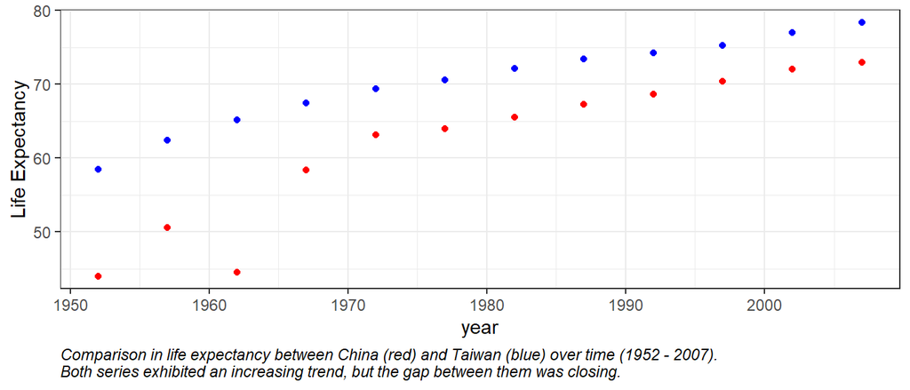

```r
cap <- "Comparison in life expectancy between China (red) and Taiwan (blue) over time (1952 - 2007).
Both series exhibited an increasing trend, but the gap between them was closing."
gap_wide %>%
  ggplot(aes(x = year)) +
  labs(y = "Life Expectancy", caption = cap) +
  geom_point(aes(y = China), colour = "red") +
  geom_point(aes(y = Taiwan), colour = "blue") +
  theme_bw()+
  theme(plot.caption = element_text(hjust = 0,face= "italic"))
```

### 3. Re-lengthen the data.

Codes and results:

```r
gap_wide %>%
  pivot_longer(cols = -year,
               names_to = "country",
               values_to = "lifeExp") %>%
  DT::datatable()
```

|  | year | country | lifeExp |
| --- | --- | --- | --- |
| 1 | 1952 | Afghanistan | 28.801 |
| 2 | 1952 | Bahrain | 50.939 |
| 3 | 1952 | Bangladesh | 37.484 |
| 4 | 1952 | Cambodia | 39.417 |
| 5 | 1952 | China | 44 |
| 6 | 1952 | Hong Kong, China | 60.96 |
| 7 | 1952 | India | 37.373 |
| 8 | 1952 | Indonesia | 37.468 |
| 9 | 1952 | Iran | 44.869 |
| 10 | 1952 | Iraq | 45.32 |

[output cut: 386 more lines]

## Exercise 2 Multivariate Data Reshaping (Option 1)

### 1 Make a tibble with one row per year, and columns for life expectancy and GDP per capita (or two other numeric variables) for two or more countries.

Codes and results:

```r
gap_wide_2 <- gapminder %>%
  filter(country == "Canada" | country == "Brazil") %>% #filter the dataset to display only two countries
  pivot_wider(id_cols = year,
              names_from = country,
              names_sep = "_",
              values_from = c(lifeExp, gdpPercap))
DT::datatable(gap_wide_2)
```

|  | year | lifeExp_Brazil | lifeExp_Canada | gdpPercap_Brazil | gdpPercap_Canada |
| --- | --- | --- | --- | --- | --- |
| 1 | 1952 | 50.917 | 68.75 | 2108.944355 | 11367.16112 |
| 2 | 1957 | 53.285 | 69.96 | 2487.365989 | 12489.95006 |
| 3 | 1962 | 55.665 | 71.3 | 3336.585802 | 13462.48555 |
| 4 | 1967 | 57.632 | 72.13 | 3429.864357 | 16076.58803 |
| 5 | 1972 | 59.504 | 72.88 | 4985.711467 | 18970.57086 |
| 6 | 1977 | 61.489 | 74.21 | 6660.118654 | 22090.88306 |
| 7 | 1982 | 63.336 | 75.76 | 7030.835878 | 22898.79214 |
| 8 | 1987 | 65.205 | 76.86 | 7807.095818 | 26626.51503 |
| 9 | 1992 | 67.057 | 77.95 | 6950.283021 | 26342.88426 |
| 10 | 1997 | 69.388 | 78.61 | 7957.980824 | 28954.92589 |

[output cut: 2 more lines]

### 2. Re-lengthen the data.

Codes and results:

```r
gap_wide_2 %>%
  pivot_longer(cols = -year,
               names_to = c(".value","country"),
               names_sep = "_") %>%
  DT::datatable()
```

|  | year | country | lifeExp | gdpPercap |
| --- | --- | --- | --- | --- |
| 1 | 1952 | Brazil | 50.917 | 2108.944355 |
| 2 | 1952 | Canada | 68.75 | 11367.16112 |
| 3 | 1957 | Brazil | 53.285 | 2487.365989 |
| 4 | 1957 | Canada | 69.96 | 12489.95006 |
| 5 | 1962 | Brazil | 55.665 | 3336.585802 |
| 6 | 1962 | Canada | 71.3 | 13462.48555 |
| 7 | 1967 | Brazil | 57.632 | 3429.864357 |
| 8 | 1967 | Canada | 72.13 | 16076.58803 |
| 9 | 1972 | Brazil | 59.504 | 4985.711467 |
| 10 | 1972 | Canada | 72.88 | 18970.57086 |

[output cut: 14 more lines]

## Exercise 3: Table Joins

load required datasets

```r
guest <- read_csv("https://raw.githubusercontent.com/STAT545-UBC/Classroom/master/data/wedding/attend.csv")
email <- read_csv("https://raw.githubusercontent.com/STAT545-UBC/Classroom/master/data/wedding/emails.csv")
```

### 1. For each guest in the guestlist (guest tibble), add a column for email address, which can be found in the email tibble.

Note: In the email tibble, each email seems corresponding to a party instead of individual name. Firstly, I will use separate_rows to make each person gets their own row, then join the two tibbles by the name column using left join.

Codes and results:

```r
email_name <- email %>%
  separate_rows(guest, sep = ", ")
colnames(email_name)[1] <- "name" #change the column name in the email tibble to match the guest tibble
DT::datatable(guest_email <- guest %>%
  left_join(email_name, by = "name") %>%
  select(party, name, email,everything()))
```

|  | party | name | email | meal_wedding | meal_brunch | attendance_wedding | attendance_brunch | attendance_golf |
| --- | --- | --- | --- | --- | --- | --- | --- | --- |
| 1 | 1 | Sommer Medrano | sommm@gmail.com | PENDING | PENDING | PENDING | PENDING | PENDING |
| 2 | 1 | Phillip Medrano | sommm@gmail.com | vegetarian | Menu C | CONFIRMED | CONFIRMED | CONFIRMED |
| 3 | 1 | Blanka Medrano | sommm@gmail.com | chicken | Menu A | CONFIRMED | CONFIRMED | CONFIRMED |
| 4 | 1 | Emaan Medrano | sommm@gmail.com | PENDING | PENDING | PENDING | PENDING | PENDING |
| 5 | 2 | Blair Park | bpark@gmail.com | chicken | Menu C | CONFIRMED | CONFIRMED | CONFIRMED |
| 6 | 2 | Nigel Webb | bpark@gmail.com |  |  | CANCELLED | CANCELLED | CANCELLED |
| 7 | 3 | Sinead English | singlish@hotmail.ca | PENDING | PENDING | PENDING | PENDING | PENDING |
| 8 | 4 | Ayra Marks | marksa42@gmail.com | vegetarian | Menu B | PENDING | PENDING | PENDING |
| 9 | 5 | Atlanta Connolly |  | PENDING | PENDING | PENDING | PENDING | PENDING |
| 10 | 5 | Denzel Connolly |  | fish | Menu B | CONFIRMED | CONFIRMED | CONFIRMED |

[output cut: 20 more lines]

### 2. Who do we have emails for, yet are not on the guestlist?

Note: This can be achieved by antijoining the guestlist to the email list

Codes and results:

```r
(newlist <- email_name %>%
  anti_join(guest, by = "name"))
```

```
## # A tibble: 3 x 2
##   name            email
##   <chr>           <chr>
## 1 Turner Jones    tjjones12@hotmail.ca
## 2 Albert Marshall themarshallfamily1234@gmail.com
## 3 Vivian Marshall themarshallfamily1234@gmail.com
```

### 3. Make a guestlist that includes everyone we have emails for (in addition to those on the original guestlist).

Note: This can be achieved by just stacking the original guestlist and the list created in the previous step together using the bind_rows() function.

Codes and results:

```r
DT::datatable(bind_rows(newlist, guest_email))
```

|  | name | email | party | meal_wedding | meal_brunch | attendance_wedding | attendance_brunch | attendance_golf |
| --- | --- | --- | --- | --- | --- | --- | --- | --- |
| 1 | Turner Jones | tjjones12@hotmail.ca |  |  |  |  |  |  |
| 2 | Albert Marshall | themarshallfamily1234@gmail.com |  |  |  |  |  |  |
| 3 | Vivian Marshall | themarshallfamily1234@gmail.com |  |  |  |  |  |  |
| 4 | Sommer Medrano | sommm@gmail.com | 1 | PENDING | PENDING | PENDING | PENDING | PENDING |
| 5 | Phillip Medrano | sommm@gmail.com | 1 | vegetarian | Menu C | CONFIRMED | CONFIRMED | CONFIRMED |
| 6 | Blanka Medrano | sommm@gmail.com | 1 | chicken | Menu A | CONFIRMED | CONFIRMED | CONFIRMED |
| 7 | Emaan Medrano | sommm@gmail.com | 1 | PENDING | PENDING | PENDING | PENDING | PENDING |
| 8 | Blair Park | bpark@gmail.com | 2 | chicken | Menu C | CONFIRMED | CONFIRMED | CONFIRMED |
| 9 | Nigel Webb | bpark@gmail.com | 2 |  |  | CANCELLED | CANCELLED | CANCELLED |
| 10 | Sinead English | singlish@hotmail.ca | 3 | PENDING | PENDING | PENDING | PENDING | PENDING |

[output cut: 23 more lines]